# Analyzing Demographic and Foot Traffic Data in Philadelphia

[figure not shown]

Photo by [Prasad Panchakshari](https://unsplash.com/@pkprasad1996?utm_source=unsplash&utm_medium=referral&utm_content=creditCopyText) on [Unsplash](https://unsplash.com/?utm_source=unsplash&utm_medium=referral&utm_content=creditCopyText)

# Project Overview

What factors draw customers to visit their favorite stores, even in a pandemic? In an new era of reduced travel and extra safety precautions, which brands have prevailed so far?

These are some of the questions our team sought to answer through our capstone project as considered the economic impacts of the COVID-19 pandemic. By analyzing consumer shopping behavior, we hope to find trends about how people spend money in their communities.

## Overview of Data Sources

We've combined data from multiple sources:

- [SafeGraph Foot Traffic Data](https://www.safegraph.com/) - SafeGraph’s places dataset includes a breadth of information about physical places in the US & Canada. This includes core location information, spatial hierarchy metadata, place traffic data, and more.
- [Economic Opportunity Insights Tracker](https://github.com/OpportunityInsights/EconomicTracker) - combines anonymized data from leading private companies – from credit card processors to payroll firms – to provide a real-time picture of indicators such as employment rates, consumer spending, and job postings across counties, industries, and income groups.
- [NOAA Historical Weather Data](https://www.ncdc.noaa.gov/cdo-web/) - Climate Data Online (CDO) provides free access to NCDC's archive of global historical weather and climate data in addition to station history information. These data include quality controlled daily, monthly, seasonal, and yearly measurements of temperature, precipitation, wind, and degree days as well as radar data and 30-year Climate Normals.
- [Google Mobility Reports](https://www.google.com/covid19/mobility/) - These Community Mobility Reports aim to provide insights into what has changed in response to policies aimed at combating COVID-19. The reports chart movement trends over time by geography, across different categories of places such as retail and recreation, groceries and pharmacies, parks, transit stations, workplaces, and residential.

### The addition of each dataset allows us to ask more questions about these stores, including:

- How has COVID-19 affected foot traffic to brick-and-mortar stores?
- Are there any categories of POIs that have seen increased foot traffic as a result of COVID-19 (Hospitals, drug stores, etc.)?
- How does weather affect foot traffic to different categories of stores? Do certain POIs become harder to access in different weather conditions?
- How does changes in consumer mobility correlate with foot traffic?
- Does the weather have any affect on consumer mobility?
- How has COVID-19 affected consumer mobility?
- Which policy event decreased consumer mobility and foot traffic the most?

# Data Cleaning Methodology

[figure not shown]

```python
#load common utilities
import os
from datetime import datetime
import glob

#load data analysis packages
import numpy as np
import pandas as pd
import matplotlib
import matplotlib.pyplot as plt
import seaborn as sb
sb.set()
import squarify
from pywaffle import Waffle


import folium  #needed for interactive map
from folium.plugins import HeatMap
import geopy
from geopy.distance import geodesic

#set display options
from pylab import rcParams
rcParams['figure.figsize'] = 15, 10

pd.set_option('display.max_rows', 10)
pd.set_option('display.max_columns', None)

from IPython.display import HTML, IFrame

#set working directory
rootdir = os.getcwd()
data_path = "../data"

import sys

sys.path.append('../src/scripts/')

import sg

philly_center = [39.9526, -75.1652]
```

# Taking a closer look at SafeGraph's Point-of-Interest (POI) datasets

SafeGraph is an industry-leading data company that brings together highly accturate data from thousands of sources to deliver deep insights on millions of locations where consumers spend their money. This data is updated monthly to accurately account for store openings and closings. Safegraph offers three categories of data on their POI locations:

1. **Core Places** - Basic business information including address, phone number, category, and open/closed status.
2. **Geometry** - Building footprints with spatial hierarchy for all POIs in the Core dataset.
3. **Patterns** - Foot-traffic insights for places derived from anonymized mobile devices.

> "Our customers trust SafeGraph data to be clean and free of unnecessary noise. Our algorithms work over-time to remove and filter out irrelevant POIs and errors in the data. Better data means better decisions for your business." - SafeGraph

Below we will be taking a look at a monthly data extract containing POI data for Wawa locations in and around the Philadelphia area. In addition to the main dataset, we will be joining it to an additional file that Sagefraph provides that details the sample size of devices measured in each census block group (we'll explore this further a little later on). Safegraph states that they get a ~10% sample size of device data from their providers, and does their best to make sure they have a representative demographic sample. You can read more about how they tackle bias in their data collection in this [blog post](https://www.safegraph.com/blog/measuring-and-correcting-sampling-bias-for-accurate-demographic-analysis).

**Census Block Group**

A Census Block Group is a geographical unit used by the United States Census Bureau which is between the Census Tract and the Census Block. It is the smallest geographical unit for which the bureau publishes sample data, i.e. data which is only collected from a fraction of all households.

We will also be joining this data with SafeGraph's [Open Census Data](https://www.safegraph.com/open-census-data), a standardized and processed version of the U.S. Census Bureau's American Community Survey, to get the estimated population of each census block group.

```python
#define datatypes
dtypes = {
    "naics_code" : "object",
    "postal_code": "object",
    "phone_number": "object",
    "poi_cbg": "object"
}
#read in SafeGraph data, joined with additional datasets
safegraph_wawa_october = pd.read_csv(f"{data_path}/raw/safegraph/wawa/oct/oct.csv", dtype=dtypes).merge(
    pd.read_csv(f'{data_path}/raw/safegraph/wawa/oct/home_panel_summary.csv', usecols=['census_block_group', 'number_devices_residing'], dtype={"census_block_group": "object"}),
    left_on='poi_cbg', right_on='census_block_group', how='left'
).merge(
    pd.read_csv(f"{data_path}/raw/census/data/cbg_b01.csv", usecols=['census_block_group','B01001e1'], dtype={'census_block_group': 'object'}),
    on='census_block_group', how='left'
).rename(columns={"B01001e1":'cbg_pop'})

#read in additional census data for later
cbgs = pd.read_csv(f"{data_path}/raw/census/metadata/cbg_geographic_data.csv", usecols=['census_block_group', 'longitude', 'latitude'], dtype={"census_block_group": "object"})

safegraph_wawa_october.head()
```

|  | placekey | safegraph_place_id | parent_placekey | parent_safegraph_place_id | location_name | safegraph_brand_ids | brands | top_category | sub_category | category_tags | naics_code | latitude | longitude | street_address | city | region | postal_code | iso_country_code | phone_number | open_hours | opened_on | closed_on | tracking_opened_since | tracking_closed_since | date_range_start | date_range_end | raw_visit_counts | raw_visitor_counts | visits_by_day | … |
| --- | --- | --- | --- | --- | --- | --- | --- | --- | --- | --- | --- | --- | --- | --- | --- | --- | --- | --- | --- | --- | --- | --- | --- | --- | --- | --- | --- | --- | --- | --- |
| 0 | zzw-222@628-p8n-cnq | sg:57221f3709624c3b8fd6df6e07e8ec1b | NaN | NaN | Wawa | SG_BRAND_fa5bda016924cdc09a52f985ffb8b6e9 | Wawa | Grocery Stores | Convenience Stores | NaN | 445120 | 40.036273 | -75.070238 | 6460 Bustleton Ave | Philadelphia | PA | 19149 | US | +12155332110 | NaN | NaN | NaN | 2019-12 | 2019-07 | 2020-10-01T00:00:00-04:00 | 2020-11-01T00:00:00-04:00 | 733.0 | 515.0 | [29,28,21,20,26,25,21,29,23,33,22,23,32,19,19,... | … |
| 1 | 222-222@63s-dw8-bx5 | sg:14ce4ee122e14a7a8f41b969af9e46e9 | NaN | NaN | Wawa | SG_BRAND_fa5bda016924cdc09a52f985ffb8b6e9 | Wawa | Grocery Stores | Convenience Stores | NaN | 445120 | 39.891192 | -75.241896 | 8220 Bartram Ave | Philadelphia | PA | 19153 | US | +12154920824 | NaN | NaN | NaN | 2019-12 | 2019-07 | 2020-10-01T00:00:00-04:00 | 2020-11-01T00:00:00-04:00 | 2215.0 | 1459.0 | [104,76,71,67,68,53,61,89,70,64,83,64,59,65,93... | … |
| 2 | 224-222@628-qx3-grk | sg:f6b2db814d5f440a98af73e502b160e4 | NaN | NaN | Wawa | SG_BRAND_fa5bda016924cdc09a52f985ffb8b6e9 | Wawa | Grocery Stores | Convenience Stores | NaN | 445120 | 39.802768 | -74.950869 | 201 W White Horse Pike | Berlin | NJ | 08009 | US | +18567685117 | NaN | NaN | NaN | 2019-12 | 2019-07 | 2020-10-01T00:00:00-04:00 | 2020-11-01T00:00:00-04:00 | 1298.0 | 765.0 | [32,44,56,44,33,38,48,53,70,49,47,36,36,31,32,... | … |
| 3 | zzy-222@63s-dvs-yqf | sg:7f5feacb04de468eb7d92880813b5389 | NaN | NaN | Wawa | SG_BRAND_fa5bda016924cdc09a52f985ffb8b6e9 | Wawa | Grocery Stores | Convenience Stores | NaN | 445120 | 39.941005 | -75.272337 | 67 N Lansdowne Ave | Lansdowne | PA | 19050 | US | +16106235430 | NaN | NaN | NaN | 2019-12 | 2019-07 | 2020-10-01T00:00:00-04:00 | 2020-11-01T00:00:00-04:00 | 915.0 | 515.0 | [25,38,33,19,34,24,30,33,38,40,21,27,20,28,26,... | … |
| 4 | 229-222@628-p8d-z2k | sg:bc8b48dfd5734efeaf9d509068552e5f | NaN | NaN | Wawa | SG_BRAND_fa5bda016924cdc09a52f985ffb8b6e9 | Wawa | Grocery Stores | Convenience Stores | NaN | 445120 | 40.012014 | -75.068135 | 5597 Tulip St | Philadelphia | PA | 19124 | US | +12677687176 | NaN | NaN | NaN | 2019-12 | 2019-07 | 2020-10-01T00:00:00-04:00 | 2020-11-01T00:00:00-04:00 | 1365.0 | 818.0 | [56,61,51,39,26,44,47,42,48,47,38,55,59,54,47,... | … |

## Creating a function `get_sg_data()` to repeat this process for any POI and month

```python
def get_sg_data(poi_name, month):
    dtypes = {
    "naics_code" : "object",
    "postal_code": "object",
    "phone_number": "object",
    "poi_cbg": "object"
}
    #read in SafeGraph data, joined with additional datasets
    safegraph_df = pd.read_csv(f"{data_path}/raw/safegraph/{poi_name}/{month}/{month}.csv", dtype=dtypes).merge(
        pd.read_csv(f'{data_path}/raw/safegraph/{poi_name}/{month}/home_panel_summary.csv', usecols=['census_block_group', 'number_devices_residing'], dtype={"census_block_group": "object"}),
        left_on='poi_cbg', right_on='census_block_group', how='left'
    ).merge(
        pd.read_csv(f"{data_path}/raw/census/data/cbg_b01.csv", usecols=['census_block_group','B01001e1'], dtype={'census_block_group': 'object'}),
        on='census_block_group', how='left'
    ).rename(columns={"B01001e1":'cbg_pop'})

    return safegraph_df
```

# Exploratory Data Analysis on a single store

As you can see, there is a wealth of information about each of our store locations. When looking at the Patterns portion of the dataset, it becomes apparent that these columns are not easily able to be processed right away due to the different data embeddings encoded as strings. However, with a little elbow grease and Python data manipulation magic, we can uncover some pretty fascinating insights about our POI locations.

## Creating the `sg` module

In order assist with all of the data manipulation steps needed to disect the foot traffic pattern columns and massage them into a workable format, we created and packaged several functions under the `sg` module to more efficiently process each store location. The source code of this module can be found at `/src/scripts/sg.py`.

### Let's take a look at the first store in our dataset and do some basic analysis on some of the main columns:

```python
store = safegraph_wawa_october.iloc[0]
store
```

```
placekey                                                   zzw-222@628-p8n-cnq
safegraph_place_id                         sg:57221f3709624c3b8fd6df6e07e8ec1b
parent_placekey                                                            NaN
parent_safegraph_place_id                                                  NaN
location_name                                                             Wawa
                                                   ...
poi_cbg                                                           421010313003
visitor_daytime_cbgs         {"421010312002":9,"421010313004":9,"4210103130...
census_block_group                                                421010313003
number_devices_residing                                                  287.0
cbg_pop                                                                 1074.0
Name: 0, Length: 44, dtype: object
```

## Analyzing `visits_by_day` column using the `sg.calc_visits_by_day()` function

The `visits_by_day` column of the SageFraph dataset containes a string-encoded list of the number of visits to the POI location each day of the month. This list doesn't become useful until to map the values to the actual days and dates they correspond to, so that's what the `sg.calc_visits_by_day()` function is designed to do. In a nutshell, it uses the `date_range_start` and `date_range_end` columns from the POI record to create a pandas `date_range` index to create a row for every day in the date range. Then, it takes the list of daily visitsand maps the first value to day 1, second value to day 2, and so on. Calling the function,which takes a pandas Series object representing a single store and observation in the dataset and returns the below dataframe:

```python
#output the raw visits_by_day_column
print(store.visits_by_day)

#use sg.calc_visits_by_day to generate daily visit dataframe
visits = sg.calc_visits_by_day(store)
visits
```

```
[29,28,21,20,26,25,21,29,23,33,22,23,32,19,19,22,36,26,21,22,33,24,33,35,30,36,21,11,2,4,7]
```

|  | id | visits |
| --- | --- | --- |
| 2020-10-01 | sg:57221f3709624c3b8fd6df6e07e8ec1b | 29 |
| 2020-10-02 | sg:57221f3709624c3b8fd6df6e07e8ec1b | 28 |
| 2020-10-03 | sg:57221f3709624c3b8fd6df6e07e8ec1b | 21 |
| 2020-10-04 | sg:57221f3709624c3b8fd6df6e07e8ec1b | 20 |
| 2020-10-05 | sg:57221f3709624c3b8fd6df6e07e8ec1b | 26 |
| ... | ... | ... |
| 2020-10-27 | sg:57221f3709624c3b8fd6df6e07e8ec1b | 21 |
| 2020-10-28 | sg:57221f3709624c3b8fd6df6e07e8ec1b | 11 |
| 2020-10-29 | sg:57221f3709624c3b8fd6df6e07e8ec1b | 2 |
| 2020-10-30 | sg:57221f3709624c3b8fd6df6e07e8ec1b | 4 |
| 2020-10-31 | sg:57221f3709624c3b8fd6df6e07e8ec1b | 7 |

31 rows × 2 columns

## Plotting the`visits` dataframe returned by `sg.calc_visits_by_day()`

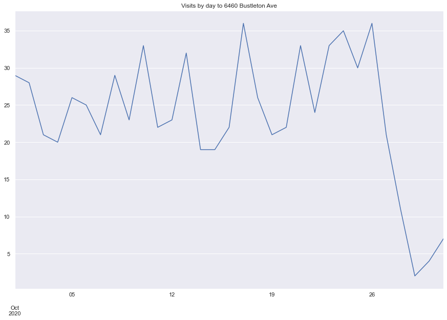

```python
visits.visits.plot().set_title(f"Visits by day to {store.street_address}")
```

## SafeGraph Sampling and Estimating True Visits By Day

As discussed earlier, Safegraph receives a ~10% sample of the available device data, so the foot traffic numbers reported in the dataset are a lot lower than the real life visits. In order to correct for this sampling, when required, we must use the `visitor_home_cbgs` column that disaggregates the visitors by their home census block group. We then use our supplementary datasets to extrapolate and estimate the real number of visits based on SafeGraph's reported sample size for each of the census block groups and the actual reported 2016 population of each census block group. We created the `sg.calc_true_values_by_day()` function to perform these calculations based on this [example](https://docs.google.com/spreadsheets/d/1A0KLTyRzx2DrYbagyi4_W4bKmgHqIsKGnq4O4W-tGy4/edit#gid=2092927992).

Below is the returned dataframe from calling `sg.calc_true_visits_by_day()` on the same `store` Series:

```python
true_visits = sg.calc_true_visits_by_day(store)
true_visits
```

|  | id | visits | true_visits |
| --- | --- | --- | --- |
| 2020-10-01 | sg:57221f3709624c3b8fd6df6e07e8ec1b | 29 | 125.297148 |
| 2020-10-02 | sg:57221f3709624c3b8fd6df6e07e8ec1b | 28 | 120.976557 |
| 2020-10-03 | sg:57221f3709624c3b8fd6df6e07e8ec1b | 21 | 90.732418 |
| 2020-10-04 | sg:57221f3709624c3b8fd6df6e07e8ec1b | 20 | 86.411826 |
| 2020-10-05 | sg:57221f3709624c3b8fd6df6e07e8ec1b | 26 | 112.335374 |
| ... | ... | ... | ... |
| 2020-10-27 | sg:57221f3709624c3b8fd6df6e07e8ec1b | 21 | 90.732418 |
| 2020-10-28 | sg:57221f3709624c3b8fd6df6e07e8ec1b | 11 | 47.526505 |
| 2020-10-29 | sg:57221f3709624c3b8fd6df6e07e8ec1b | 2 | 8.641183 |
| 2020-10-30 | sg:57221f3709624c3b8fd6df6e07e8ec1b | 4 | 17.282365 |
| 2020-10-31 | sg:57221f3709624c3b8fd6df6e07e8ec1b | 7 | 30.244139 |

31 rows × 3 columns

## Plotting the `popularity_by_hour` column

```
[21,21,26,20,22,31,61,73,57,59,63,48,61,70,62,54,68,65,69,55,43,41,35,29]

{1: 21, 2: 21, 3: 26, 4: 20, 5: 22, 6: 31, 7: 61, 8: 73, 9: 57, 10: 59, 11: 63, 12: 48, 13: 61, 14: 70, 15: 62, 16: 54, 17: 68, 18: 65, 19: 69, 20: 55, 21: 43, 22: 41, 23: 35, 24: 29}
```

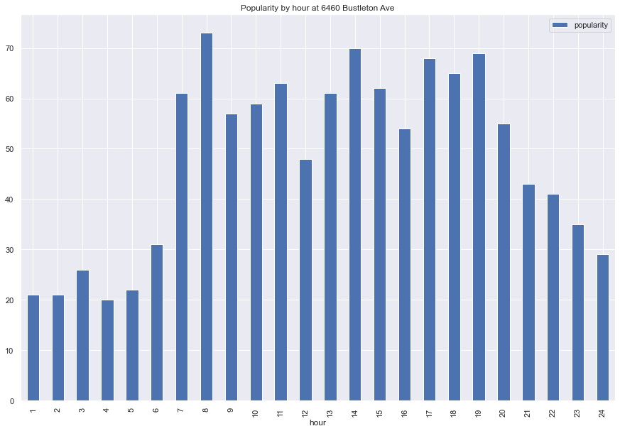

```python
#print original popularity_by_hour column
print(store.popularity_by_hour)
print()
#create a dictionary mapping of hour to popularity
d = dict(zip([*range(1,25)], eval(store.popularity_by_hour)))
print(d)

pd.DataFrame(data={"hour":d.keys(), "popularity":d.values()}).plot.bar('hour','popularity').set_title(f"Popularity by hour at {store.street_address}")
```

## Plotting the `device_type` column

```
{"android":353,"ios":161}
```

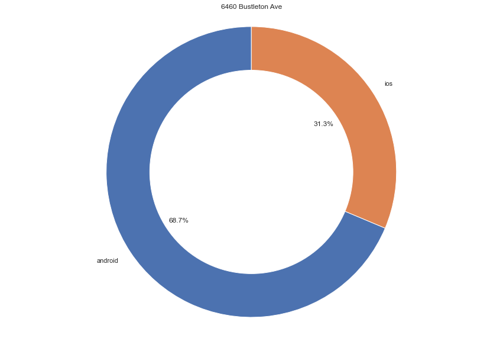

```python
print(store.device_type)

device_type = eval(store.device_type)

fig1, ax1 = plt.subplots()
ax1.pie(device_type.values(), labels=device_type.keys(), autopct='%1.1f%%',
        shadow=False, startangle=90)
ax1.axis('equal')  # Equal aspect ratio ensures that pie is drawn as a circle.
my_circle=plt.Circle( (0,0), 0.7, color='white')
p=plt.gcf()
p.gca().add_artist(my_circle)
plt.title(store.street_address)
plt.show()
```

## Plotting the `bucketed_dwell_time` column

```
{"<5":44,"5-10":393,"11-20":161,"21-60":85,"61-120":19,"121-240":11,">240":20}
```

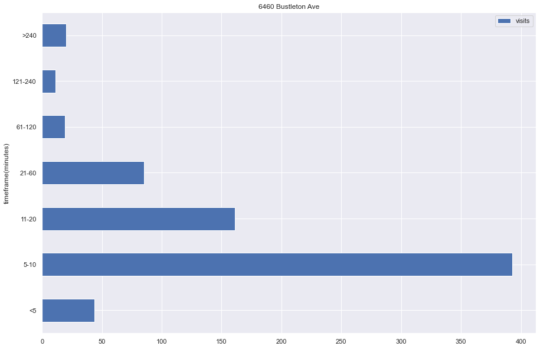

```python
print(store.bucketed_dwell_times)
d = eval(store.bucketed_dwell_times)
pd.DataFrame(data={'timeframe(minutes)':d.keys(), 'visits':d.values()}).plot.barh('timeframe(minutes)', 'visits').set_title(store.street_address)
```

## Plotting the `related_same_day_brand` column

```
{"LUKOIL North America":50,"Philadelphia Sports Club":10,"Dunkin'":10,"Rite Aid":10,"The Home Depot":10,"McDonald's":10,"Family Dollar Stores":9,"Dollar Tree":8}
```

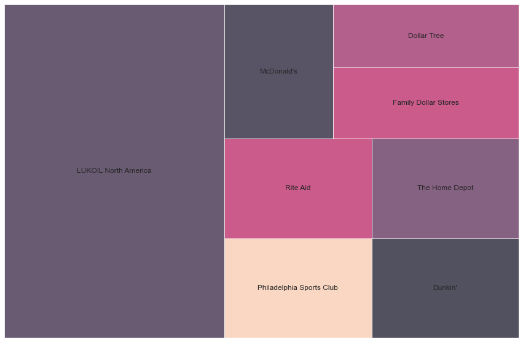

```python
print(store.related_same_day_brand)

d = eval(store.related_same_day_brand)

squarify.plot(sizes=d.values(), label=d.keys(), alpha=.7)
plt.axis('off')
plt.show()
```

## Plotting the `related_same_month_brand` column

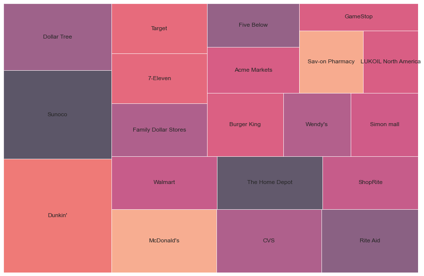

```python
d = eval(store.related_same_month_brand)

squarify.plot(sizes=d.values(), label=d.keys(), alpha=.7)
plt.axis('off')
plt.show()
```

## Mapping Store Location vs. Visitor Home Census Block Location

By plotting this visualization, we can get a view of how far people are traveling to this store from their home location. It makes sense that there are a lot of visitors (block markers) that live near store (red marker), and it can be safely assumed that the visitors who live farther away visit that location either on their way to work or on the way to a different part of town.

Given that we only have data from the past few months, it makes sense that there are very few black markers vaery far away from the store given reduced travel due to COVID-19. If we can get access to any pre-covid data, it will be interesting to see how far the black markers get spread throughout the country as a possible micro-view into the overall tourism trends of Philadelphia.

```python
visitor_cbgs = list(eval(store.visitor_home_cbgs))
location = cbgs[cbgs['census_block_group'] == store.poi_cbg].iloc[0]

folium_map = folium.Map(location=[location.latitude, location.longitude],
                        zoom_start=13,
                        tiles="OpenStreetMap")

for visitor in visitor_cbgs:
    m = cbgs[cbgs['census_block_group'] == visitor].iloc[0]
    folium.CircleMarker(location=[m.latitude, m.longitude], radius=5, color='black', fill=False)\
    .add_child(folium.Popup(f"Distance to store: {round(geodesic([location.latitude, location.longitude], [m.latitude, m.longitude]).miles, 2)} miles"))\
    .add_to(folium_map)
    #add label with distance to store

folium.CircleMarker(location=[location.latitude, location.longitude], radius=10, color='red', fill=True).add_to(folium_map)

folium_map
```

Make this Notebook Trusted to load map: File -> Trust Notebook

[interactive chart not shown]

# Analyzing Multiple Stores and Brands

We just saw how much insight can be gained from just one SageGraph store record. However, if we look at the same data points across hundreds of stores and multiple brands, the possibilities are nearly endless. In the following code blocks, we take two brands, Wawa and Starbucks, and plot each of their store locations on a map. You can see that there are no particular areas where one brand has a monopoly over the location. Where one store brand is, you can probably find the other nearby.

```python
folium_map = folium.Map(location=philly_center,
                        zoom_start=12,
                        tiles="OpenStreetMap")

for i, store_location in safegraph_wawa_october.iterrows():
    folium.CircleMarker(location=[store_location.latitude, store_location.longitude], radius=4, color='red', fill=True).add_to(folium_map)

safegraph_starbucks_october = get_sg_data("starbucks", "oct")

for i, store_location in safegraph_starbucks_october.iterrows():
    folium.CircleMarker(location=[store_location.latitude, store_location.longitude], radius=4, color='green', fill=True).add_to(folium_map)

folium_map
```

Make this Notebook Trusted to load map: File -> Trust Notebook

[interactive chart not shown]

## Here, we make the same plot, but this time make the size of the markers proportional to their volume of foot traffic

With some exceptions including Center City Philadelphia, the majority of the biggest markers are Wawa locations, which suggests that Wawa has the largest share of foot traffic in this particular match-up

```python
folium_map = folium.Map(location=philly_center,
                        zoom_start=12,
                        tiles="OpenStreetMap")

for i, store_location in safegraph_wawa_october.iterrows():
    folium.CircleMarker(location=[store_location.latitude, store_location.longitude], radius=(store_location.raw_visit_counts * 0.02), color='red', fill=True).add_to(folium_map)

safegraph_starbucks_october = get_sg_data("starbucks", "oct")

for i, store_location in safegraph_starbucks_october.iterrows():
    folium.CircleMarker(location=[store_location.latitude, store_location.longitude], radius=(store_location.raw_visit_counts * 0.02), color='green', fill=True).add_to(folium_map)

folium_map
```

Make this Notebook Trusted to load map: File -> Trust Notebook

[interactive chart not shown]

# Starbucks vs Wawa Foot Traffic Share: October 2020

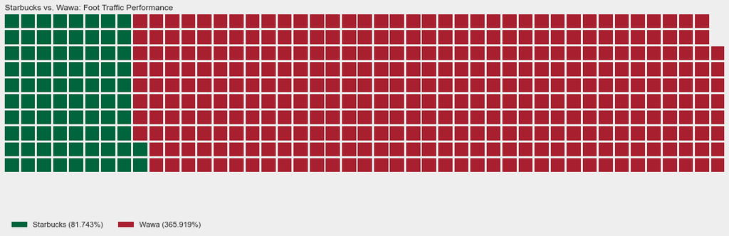

```python
s_visits = safegraph_starbucks_october['raw_visit_counts'].sum()/1000
w_visits = safegraph_wawa_october['raw_visit_counts'].sum()/1000
se_visits = safegraph_7_eleven_oct['raw_visit_counts'].sum()/1000

data = {'Starbucks': s_visits, 'Wawa': w_visits}
fig = plt.figure(
    FigureClass=Waffle,
    rows=10,
    values=data,
    colors=("#00643C", "#A8202F"),
    title={'label': 'Starbucks vs. Wawa: Foot Traffic Performance', 'loc': 'left'},
    labels=["{0} ({1}%)".format(k, v) for k, v in data.items()],
    legend={'loc': 'lower left', 'bbox_to_anchor': (0, -0.4), 'ncol': len(data), 'framealpha': 0},
)
fig.gca().set_facecolor('#EEEEEE')
fig.set_facecolor('#EEEEEE')
plt.show()
```

# Working with Census Data

As mentioned earlier, combining SageGraph's POI and foot traffic data with their Open Census dataset can provide powerful insights into the customer demographics of different brands.

We've decided to focus on this piece for the remainder of our analysis as well as our final project. Our earlier questions still valid ideas for other analytics problems, and we've included the cleaning scripts used on our other datasets in the "Reference" subfolder in the "Notebooks" directory

In order to source analyze the customer demographic data for these brands, we go through a process starting with the parsing and aggregating of the `visitor_home_cbgs` column of each store record to get the number of visitors from each census block group to each store. You can find the cleaning scripts for this process in the "Census Data Cleaning Scripts" notebook in the "References" folder. The finished dataset looks like this:

```python
pd.read_csv(f"{data_path}/processed/cbg_visits.csv")
```

|  | census_block_group | visits_wawa | visits_7_eleven |
| --- | --- | --- | --- |
| 0 | 10010202001 | 4.0 | NaN |
| 1 | 10030108002 | 4.0 | NaN |
| 2 | 10030113004 | 4.0 | NaN |
| 3 | 10279589001 | 8.0 | NaN |
| 4 | 10439645003 | 6.0 | NaN |
| ... | ... | ... | ... |
| 11726 | 550390405002 | NaN | 4.0 |
| 11727 | 550679604003 | NaN | 4.0 |
| 11728 | 560379716001 | NaN | 4.0 |
| 11729 | 720757110023 | NaN | 5.0 |
| 11730 | 721390603022 | NaN | 4.0 |

11731 rows × 3 columns

## Selecting Census Variables for Analysis

Now that we have the number of visitors from each census block group, we can then use the Open Census dataset to lookup any of the 7500 demographic indicators available, calculate the percentages between the population groups, and then apply those percentages to our number of visitors to get an estimated demographic breakdown of each brand's visitors

In order to make these processes easily repeatable across multiple brands and demographic profiles, we've created several more helper functions under the `sg` module. Our first helper function is `sg.read_census_data()` that takes as a single argument a dictionary of census variables mapped to the user-specified column name for those variables.

```python
def read_census_data(variable_dict):
    dfs = []

    data_sets = sorted(list(set([x[0:3].lower() for x in variable_dict])))
    print("Data Sets: ", data_sets)

    for data_set in data_sets:
        dfs.append(pd.read_csv(f"{data_path}/raw/census/data/cbg_{data_set}.csv", dtype={'census_block_group': "object"},
                               usecols=["census_block_group"] + [x for x in list(variable_dict.keys()) if x[0:3].lower() == data_set])\
                   .set_index('census_block_group'))

    df = pd.concat(dfs, axis=1)
    df = df.rename(columns=variable_dict)

    return df.reset_index()

read_census_data({
    "B01001e1": "total_population",
    "B02001e2": "pop_white",
    "B02001e3": "pop_black",
    "B02001e5": "pop_asian",
    "B03002e1": "pop_hispanic"
})
```

```
Data Sets:  ['b01', 'b02', 'b03']
```

|  | census_block_group | total_population | pop_white | pop_black | pop_asian | pop_hispanic |
| --- | --- | --- | --- | --- | --- | --- |
| 0 | 010010201001 | 745 | 585 | 160 | 0 | 745 |
| 1 | 010010201002 | 1265 | 1083 | 104 | 9 | 1265 |
| 2 | 010010202001 | 960 | 361 | 568 | 0 | 960 |
| 3 | 010010202002 | 1236 | 615 | 571 | 24 | 1236 |
| 4 | 010010203001 | 2364 | 1481 | 515 | 27 | 2364 |
| ... | ... | ... | ... | ... | ... | ... |
| 220328 | 721537506011 | 921 | 752 | 0 | 0 | 921 |
| 220329 | 721537506012 | 2703 | 2230 | 207 | 0 | 2703 |
| 220330 | 721537506013 | 1195 | 1085 | 25 | 0 | 1195 |
| 220331 | 721537506021 | 2005 | 1662 | 68 | 0 | 2005 |
| 220332 | 721537506022 | 736 | 588 | 0 | 0 | 736 |

220333 rows × 6 columns

## Modified `sg.read_census_data2()` function for aggregating census groups

For more numerical demographic indicators like age, there are many different number ranges that the Census tracks, with some groups being more fine-grained than others like 20 year olds and 22-24 year olds. We're more interested in looking at broader bucketed age ranges of the population, so we've created another version of the `read_census_data()` function that takes a dictionary of grouped column names mapped to a list of variable codes belonging to each group

```python
def read_census_data2(var_dict):
    flatten = lambda t: [item for sublist in t for item in sublist]
    var_list = flatten(list(var_dict.values()))
    data_sets = sorted(list(set([x[0:3].lower() for x in var_list])))
    print("Data Sets: ", data_sets)

    dfs = []
    for data_set in data_sets:
        dfs.append(pd.read_csv(f"{data_path}/raw/census/data/cbg_{data_set}.csv", dtype={'census_block_group':"object"}, usecols=["census_block_group"] + [x for x in var_list if x[0:3].lower() == data_set])\
                  .set_index('census_block_group'))

    df = pd.concat(dfs, axis=1)
    for col in var_dict:
        df[col] = np.sum(df[var_dict[col]], axis=1)

    return df[list(var_dict.keys())]


age_dict = {
    "total_population": ["B01001e1"],
    "male_20_29": ["B01001e8", "B01001e9", "B01001e10","B01001e11"],
    "male_30_39": ["B01001e12","B01001e13"],
    'female_20_29': ["B01001e32", "B01001e33", "B01001e34","B01001e35"],
    'female_30_39': ["B01001e36", "B01001e37"]
}


read_census_data2(age_dict)
```

```
Data Sets:  ['b01']
```

| census_block_group | total_population | male_20_29 | male_30_39 | female_20_29 | female_30_39 |
| --- | --- | --- | --- | --- | --- |
| 010010201001 | 745 | 38 | 55 | 55 | 61 |
| 010010201002 | 1265 | 104 | 59 | 66 | 57 |
| 010010202001 | 960 | 84 | 43 | 29 | 57 |
| 010010202002 | 1236 | 130 | 107 | 76 | 55 |
| 010010203001 | 2364 | 122 | 196 | 177 | 200 |
| ... | ... | ... | ... | ... | ... |
| 721537506011 | 921 | 96 | 25 | 75 | 17 |
| 721537506012 | 2703 | 374 | 184 | 184 | 207 |
| 721537506013 | 1195 | 147 | 14 | 139 | 10 |
| 721537506021 | 2005 | 110 | 125 | 187 | 103 |
| 721537506022 | 736 | 7 | 26 | 31 | 69 |

220333 rows × 5 columns

# Demographic Profile Helper Functions

We're in the process of creating a series of other helper functions to let us easily visualize different demographic profiles of customers across brands. These helper functions make use of the `read_census_data()` and `read_census_data2()` functions to pull the required subset of census data. A few of those demographic profiles are listed below:

### Demographic Profile: Gender

```
Data Sets:  ['b01']
```

|  | brand | est_male | est_female |
| --- | --- | --- | --- |
| 0 | wawa | 261584.766939 | 277094.233061 |
| 0 | 7_eleven | 22774.191328 | 24396.808672 |

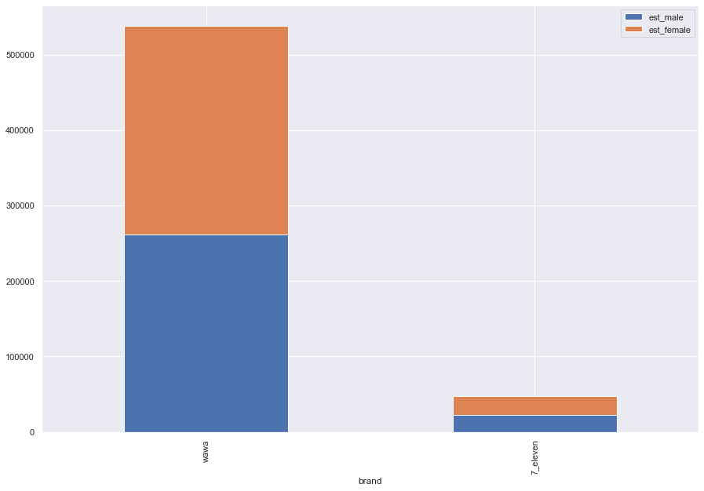

```python
data = calc_gender(['wawa', '7_eleven'])
display(data)

data.plot(kind='bar', x='brand', stacked=True)
```

### Demographic Profile: Race and Ethnicity

*Note: the helper function for this profile is not yet complete. Several subgroups still need to be added*

```
Data Sets:  ['b01', 'b02']
```

|  | brand | est_white | est_black | est_asian | est_other |
| --- | --- | --- | --- | --- | --- |
| 0 | wawa | 411909.998012 | 73329.153946 | 25851.606813 | 27588.241229 |
| 0 | 7_eleven | 33472.483575 | 8303.688045 | 2554.616549 | 2840.211831 |

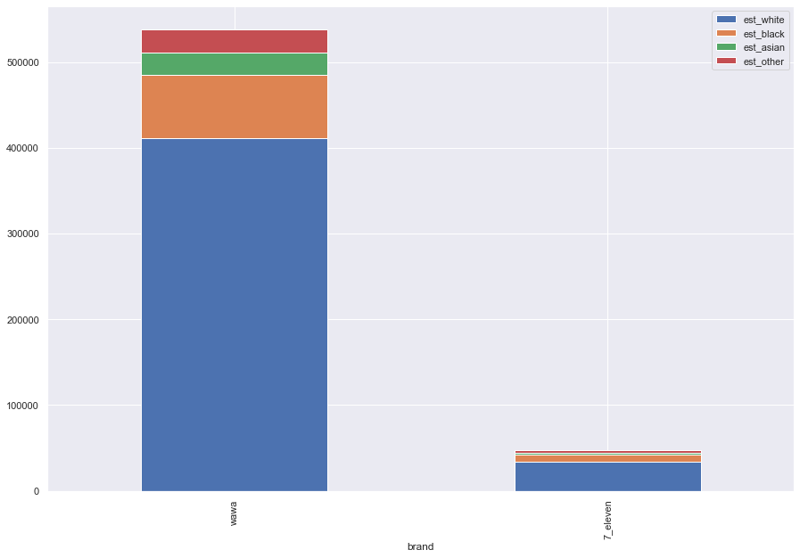

```python
data = calc_race(['wawa', '7_eleven'])
display(data)
data.plot(kind='bar', x='brand', stacked=True)
```

### Demographic Profile: Age

*Note: the helper function for this profile is not yet complete. Several subgroups still need to be added*

```
['b01']
```

|  | brand | est_20_29 | est_30_39 |
| --- | --- | --- | --- |
| 0 | wawa | 68468.779705 | 65535.192310 |
| 0 | 7_eleven | 6583.374002 | 6080.792868 |

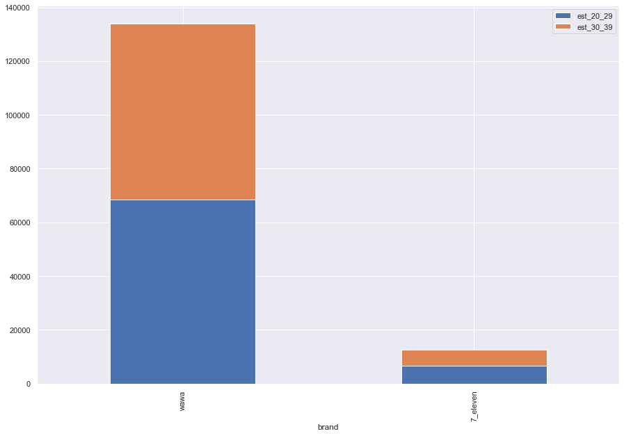

```python
data = calc_age(['wawa', '7_eleven'])
display(data)
data.plot(kind='bar', x='brand', stacked=True)
```

# Appendix

Under the "Reference" subfolder, you'll find several notebooks that go into greater detail on the data cleaning process of our datasets, as well as some additional pieces of code written to answer some of our other original questions.

- For more details on how we made the helper functions to analyze the Open Census data, check out the `Analyzing SafeGraph Census Data` notebook.
- For more details on how we made the aggregated census block group visitor datasets, check out the `Census Data Cleaning Scripts` notebook.
- For more details on the cleaning process of our other data sets, check out the `Clean_Google_Mobility` and `Additional Data Sources` notebooks.
- For a quick reference guide on how to use the Google Maps API in you jupyter notebooks, checkout the `Google Maps API Reference` notebook.